# 4. Prosjek i srednja vrijednost niza brojeva

U ovoj listi ima preko 10.000 podataka:

```python
len(zarade)
```

```
10012
```

Prosječna zarada u kompaniji je:

```python
prosjek(zarade)
```

```
3911.713044346784
```

Međutim, mediana ovog niza je:

```python
median(zarade)
```

```
600
```

Dakle, prosječna plaća u tvrtki je oko \$3912, ali median svih zarada je \\$600. To znači da polovica zaposlenika tvrtke ima zaradu od \$600 ili manje dolara. Kako je to moguće?

Da bismo shvatili što se dogodilo, moramo napraviti detaljniju analizu.

## 4.3. Filtriranje podataka

*Filtriranje podataka* znači izdvajanje podataka iz određenog skupa podataka koji nas zanimaju.

Da bismo razumjeli kako je moguće da smo u prethodnom primjeru prosječne zarade šest puta veće od srednje vrijednosti *filtriramo* iznadprosječnu zaradu. Filtriranje liste u Pythonu može se postići konstrukcijom koja izgleda ovako:

```
[x for x in Lista if Uvjet(x)]
```

Ova konstrukcija uzima sve elemente `x` liste `Lista` koji ispunjavaju `Uvjet`. Kao kad pišemo iz matematike:

$$ \{x \mid x \in \mathrm{Lista} \land \mathrm{Uvjet}(x) \} $$

U prethodnom primjeru nas zanima zarada koja je iznad prosjeka. Da bismo vidjeli koliko su i koja je zarada, prvo ćemo prosječnu zaradu staviti u varijablu, a zatim filtrirati listu `zarada`:

```python
prosjecna_zarada = prosjek(zarade)
natprosjecne_zarade = [x for x in zarade if x >= prosjecna_zarada]
```

Natprosječne zarade su:

```python
natprosjecne_zarade
```

```
[890234,
 950611,
 1211345,
 1211900,
 2341809,
 2458351,
 3211459,
 3411800,
 3811325,
 4215311,
 4231800,
 5211765]
```

i vidimo da ima svega:

```python
len(natprosjecne_zarade)
```

```
12
```

Dakle, u ovoj tvrtki 12 zaposlenih ima ogromne plaće, a 10.000 zaposlenih ima ispod prosjeka. Tih dvanaest nesrazmjerno visokih plaća povećavaju prosjek i daju dojam da "prosječna plaća u ovom poduzeću nije tako loša", iako je stvarna situacija znatno lošija.

Situacije u kojima je median vrlo različit od prosjeka govore nam da su podaci krajnje neujednačeni i da je potrebno uložiti dodatni napor da bi se razumjelo kakvo stanje opisuju.

## 4.4. Prikazivanje podataka, njihov prosjek i median

Jedan od načina da se vidi odnos između prosjeka i mediana i kako oni predstavljaju podatke je vizualizacija situacije.

Započnimo s jednim jednostavnim primjerom. Pretpostavimo da je jedan student u semestru imao sljedeće ocjene:

| Predmet | Ocjena |
| --- | --- |
| Matematika | 2 |
| Hrvatski | 4 |
| Likovni | 5 |
| Povijest | 3 |
| Tjelesni | 5 |
| Glazbeni | 4 |
| Tehnička kultura | 5 |

Podatke možemo predstaviti koristeći dvije liste, poput ove:

```python
predmeti = ["mat", "hrv", "lik", "pov", "tje", "gla", "teh"]
ocjene    = [2,        4,     5,      3,      5,    4,       5    ]
```

Želimo grafikonom pokazati njegove ocjene i imati prosječnu ocjenu označenu crvenom linijom, tako da možemo vidjeti koje su ocjene iznad prosjeka, a koje ispod.

Prvo ćemo učitati biblioteku za crtanje grafikona:

```python
import matplotlib.pyplot as plt
```

Grafikon s ocjenama možemo izvući vrlo jednostavno:

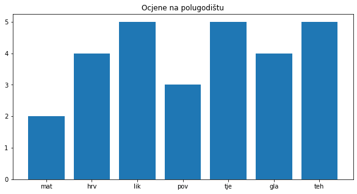

```python
plt.figure(figsize=(10,5))
plt.bar(predmeti, ocjene)
plt.title("Ocjene na polugodištu")
plt.show()
plt.close()
```

Sada želimo nacrtati crvenu liniju preko histograma koja predstavlja prosječnu ocjenu. Prvo ćemo izračunati prosječnu ocjenu `po`:

```python
po = prosjek(ocjene)
```

a zatim ćemo u gornji grafikon dodati niz podataka koji izgledaju ovako:

`[po, po, po, po, po, po, po]`

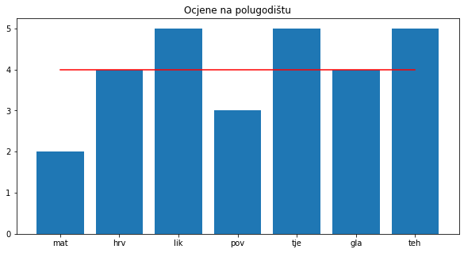

```python
plt.figure(figsize=(10,5))
plt.bar(predmeti, ocjene)
plt.plot(predmeti, [po, po, po, po, po, po, po], color="r")
plt.title("Ocjene na polugodištu")
plt.show()
plt.close()
```

Ako jedan isti podatak `s` treba ponoviti `n` puta možemo napisati kao gore:

`[s, s, s, (i tako dalje)]`

ili možemo napisati i kraće:

`[s]*n`

S oznakom `[s]*n` rekli smo Pythonu da želimo stvoriti novi niz, koji se dobiva množenjem niza [s] `n` puta. Na primjer, `[5] * 7 = [5, 5, 5, 5, 5, 5, 5]`. (Također `[6, 7, 8] * 3 = [6, 7, 8, 6, 7, 8, 6, 7, 8]`, ali ovo nam zasad neće trebati.)

Tako smo dobili sljedeću verziju programa:

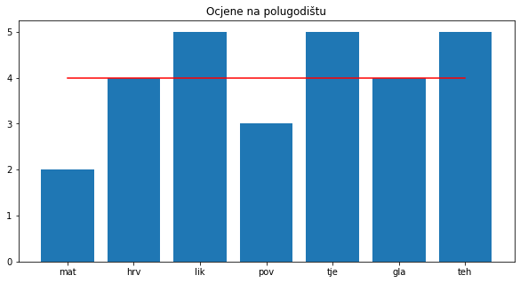

```python
plt.figure(figsize=(10,5))
plt.bar(predmeti, ocjene)
plt.plot(predmeti, [po] * len(ocjene), color="r")
plt.title("Ocjene na polugodištu")
plt.show()
plt.close()
```

Na kraju, u grafikon ćemo dodati legendu:

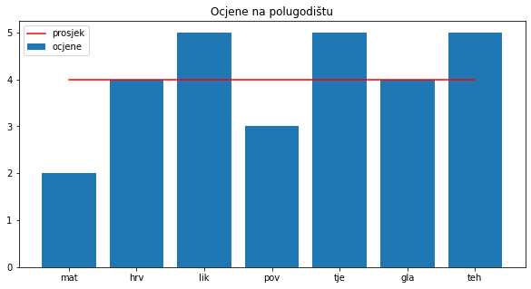

```python
plt.figure(figsize=(10,5))
plt.bar(predmeti, ocjene, label="ocjene")
plt.plot(predmeti, [po] * len(ocjene), color="r", label="prosjek")
plt.title("Ocjene na polugodištu")
plt.legend()
plt.show()
plt.close()
```

Sada vizualizirajmo `zaradu` u tvrtki o kojoj smo razgovarali u prethodnim odjeljcima. ( *Popis s kojim radimo je vrlo velik, tako da ovo može potrajati neko vrijeme! Samo budite hrabri i strpljivi!* )

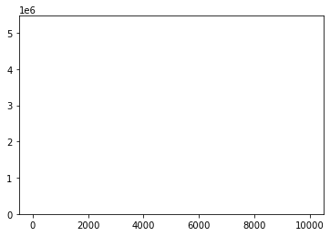

```python
n = len(zarade)
plt.bar(range(n), zarade)
plt.show()
plt.close()
```

Dakle, ne vidi se ništa...

Morat ćemo proširiti dijagram i pribjeći drugom lukavstvu. Budući da već znamo da je prosječna plaća oko \$3912 a u toj tvrtki ima samo 12 zaposlenika koji primaju toliko ili više, ograničit ćemo vrijednosti prikazane u $y$-osi. Odmah ćemo prikazati prosjek crvenom linijom..

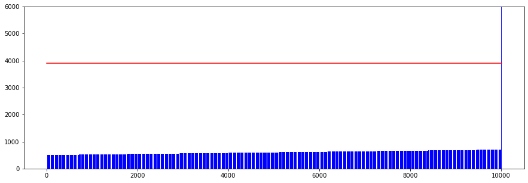

```python
n = len(zarade)
plt.figure(figsize=(15,5))
plt.bar(range(n), zarade, color="b")
plt.plot([0, n-1], [prosjecna_zarada, prosjecna_zarada], color="r")
plt.ylim(0,6000)
plt.show()
plt.close()
```

Ovaj dijagram jasno pokazuje da je nerazmjerno visoka plaća nekoliko zaposlenika "povukla prosjek za sobom".

A sada da vidimo gdje je mediaan. Predstavljamo ga kao dijagram sa samo jednom crvenom trakom u sredini niza.

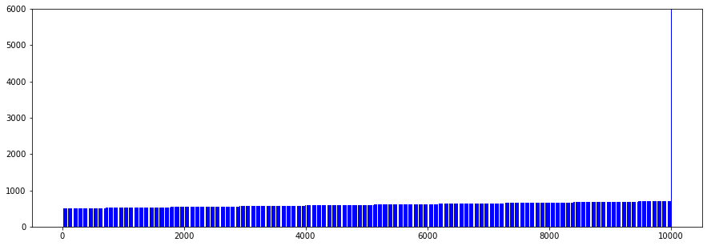

```python
n = len(zarade)
plt.figure(figsize=(15,5))
plt.bar(range(n), zarade, color="b")
plt.bar([n//2], [zarade[n//2]], color="r") # ovo je median!
plt.ylim(0,6000)
plt.show()
plt.close()
```

Gdje je crvena crtica?

Kako prikazujemo preko 10 000 podataka na relativno malom području, pojedini su stupci vrlo uski, a stupac koji predstavlja median nije vidljiv. Da bismo je istaknuli, mijenjamo širinu stupaca opcijom `width` mogućnost funkcije `bar`.

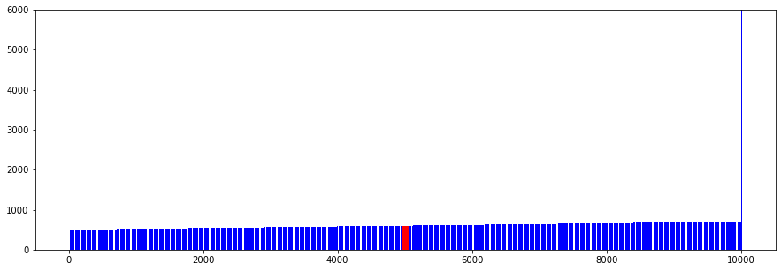

```python
n = len(zarade)
plt.figure(figsize=(15,5))
plt.bar(range(n), zarade, color="b")
plt.bar([n//2], [zarade[n//2]], color="r", width=100) # ovo je median!
plt.ylim(0,6000)
plt.show()
plt.close()
```

## 4.5. Zadaci

Zadatke napravite u Jupyteru.

**Zadatak 1.** Jedna zbirka kratkih priča za djecu ima 12 stranica - po jednu priču na svakoj stranici. Priče imaju mali broj riječi po stranicama: 271, 354, 296, 301, 333, 326, 285, 298, 327, 316, 287 i 314. Koliki je prosječan broj riječi po priči u ovoj knjizi?

**Zadatak 2.**

*(a)* Mirko iz glazbenog ima 5, 4, 5 i još jedanu ocjenu koji nije vidljivo jer se tinta prolila preko ocjene. Prosjek njegovih ocjena iz glazbenog je 4. Kolika je ocjena po kojoj se tinta prosipala?

*(b)* Koliko je još petica potrebno da Mirko stekne kako bi učitelj glazbenog krajem godine mogao zaključiti ocjenu 5? (Prema Pravilima za ocjenjivanje u osnovnim školama, ako je prosjek ocjena zabilježen u dnevniku 4,50 ili više, učitelj mora zaključiti ocjenu 5.)?

(Pomoć: Riješite zadatak pod (a) izračunajte - ne treba vam Python; rješenje problema možete izračunati u (b), ali možete ga i pogoditi eksperimentirajući s različitim mogućnostima Mirkovih ocjena u glazbi - koristite `prosjek` i `round` funkcije.)

**Zadatak 3.** Petar imeniku ima nekoliko ocjena iz informatike, sigurno manje od 10. Znamo da je 25% njegovih ocjena pet, a 12,5% njegovih ocjena tri.

*(a)* Koliko ocjena iz informatike ima Petar u imeniku?

*(b)* Koliko Petar ima petica, a koliko trojki iz informatike?

*(c)* Koliki je prosjek njegovih ocjena iz informatike, ako znamo da on nema nijednu jedinicu i nijednu dvojku?

**Zadatak 4.** Vesnine ocjene iz informatike su dane u sljedećem primjeru:

```python
vesna_ocjene = [5, 5, 4, 5, 4, 3, 4, 5, 5, 5]
```

Neka je `po`varijabla u koju stavljamo prosjek Vesninih ocjena:

```python
po = prosjek(vesna_ocjene)
```

Pogledajte pažljivo sljedeću ćeliju i odgovorite na pitanja nakon nje:

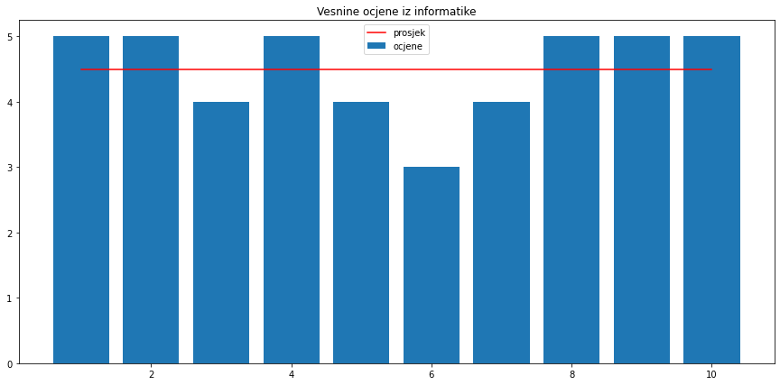

```python
plt.figure(figsize=(15,7))
plt.bar(range(1,11), vesna_ocjene, label="ocjene")
plt.plot(range(1,11), [po] * 10, color="r", label="prosjek")
plt.title("Vesnine ocjene iz informatike")
plt.legend()
plt.show()
plt.close()
```

1. Čemu služi naredba `plt.figure(figsize=(15,7))`?
2. Čemu služi naredba `range`?
3. Čemu služi naredba `legend`? Kakve ona ima veze sa parametrom `label` u funkcijama `bar` i `plot`?
4. Kako bi promijenio dimenzije grafikona tako da on bude kvadratnog oblika?
5. Kako bi promijenio boju stupića u zelenu?
6. Što znači izraz `[po] * 10` i čemu on služi u programu?
7. Kako bi uklonio legendu sa grafikona?

**Zadatak 5.** Pokažite grafikon Peterovih ocjena iz informatike u jednoj boji (to je Petar u zadatku 3), prosječnu ocjenu iz informatike u drugoj boji, a srednja ocjena njegovih ocjena u trećoj boji. Nacrtajte legendu u dijagramu.

**Zadatak 6.** Prvih deset mjesta na ATP listi dana 7.7.2019. izgleda ovako:

```python
tenisaci = ["Đoković", "Nadal", "Federer", "Thiem", "Zverev", "Tsipras", "Nishikori", "Khachanov", "Fognini", "Medvedev"]
ATP_bodovi     = [12415,      7945,    7460,      4595,   4325,     4045,       4040,        2890,        2785,      2625]
```

*(a)* Pokažite grafikon ATP bodova najboljih deset igrača na svijetu i pokažite prosječni broj bodova najboljih deset igrača na ATP listi crvenom bojom.

*(b)* Koliko ih je iznad prosjeka?

**Zadatak 7.** U zadatku 4 dane su Vesnine ocjene iz informatike. Pokažite grafikon koliko svaka od ocjena odstupa od prosjeka. Sljedeći Python programčić će vam pomoći:

```python
odstupanje = [0] * len(vesna_ocjene) # ovime smo napravili niz nula, samo da rezerviramo prostor
for i in range(len(vesna_ocjene)):
    odstupanje[i] = vesna_ocjene[i] - po
```

© 2019 [Petlja.org](https://petlja.org)